# Analyzing eCLIP and iCLIP data with DEWSeq

Sudeep Sahadevan and Thomas Schwarzl

European Molecular Biology Laboratory, Heidelberg, Germany

schwarzl@embl.de

09/17/2019

#### Abstract

The identification of RNA-binding protein targets is very similar in methodology to the detection of differentially expressed regions. Protocols such as eCLIP or iCLIP sequencing provide count data for individual nucleotides. DEWSeq implements a sliding window approach for the analysis of enriched regions in the immunoprecipitation (IP) sample compared to size-matched input (SMI) control samples. This vignette explains properties of eCLIP and iCLIP data related methods and and shows how to perform a sliding-window differentially expressed window approach to detect RNA-binding protein binidng sites.

#### Package

DEWSeq 0.99.0

# 1 Preface

## 1.1 Related packages

Other Bioconductor package with similar aim:

- *csaw*

Please get familiar with this Bioconductor package before you are using DEWSeq

- *DESeq2*
- *IHW*

## 1.2 Acknowledgements

Wolfgang Huber and Matthias Hentze for mentoring, advice and discussion. Benjamin Lang and Gian Tartaglia for great help with functional analysis and benchmarking, as well as feedback to the vignette. Mike Love, Simon Anders, Bernd Klaus and Frederick Ziebell for comments and discussion.

# 2 Introduction

## 2.1 Introduction to eCLIP sequencing

RNA-binding proteins (RBPs) play a key role in the life-time of RNAs. They are involved in RNA synthesis, stability, degradation, transport and translation and play an important layer of regulation in the cell. Over 1900 mouse and over 1400 human RBPs were detected in different high-throughput detection studies, a lot of them without known RNA-binding function (Hentze et al. 2018).

It is of great interest to detect binding sites of RBPs to study underlying mechanisms of their RNA binding. Individual nucleotide resolution crosslinking and immunoprecipitation (iCLIP) (König et al. 2010) and the derived protocol enhanced CLIP (eCLIP) (Eric L Van Nostrand et al. 2016) sequencing protocols rely on UV crosslinking inducing covalent bonds of RNA and proteins in close proximity. When reverse transcribing the RNA fragment bound to the protein, a majority of the time the reverse transcriptase will fall of at the crosslink site. Althrough eCLIP introduces updates in chemistry, the use of a size-matched input (SMI) control sample is an essential addition to the protocol which can be also adapted to iCLIP or similar protocols.

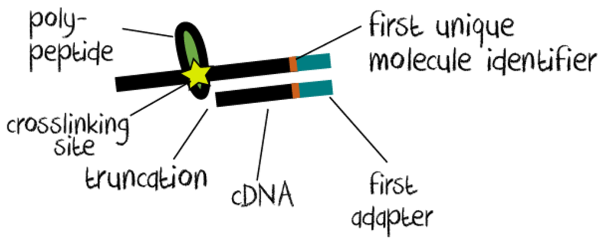

Figure 1: Crosslink site trunction at reverse transcription

In iCLIP and eCLIP, truncation events are extracted as one nucleotide position next to the cDNA fragment (aligned read). In the classical protocols real truncations cannot be distinguished from read-through reads or other reads coming for otherwise truncated reads, like it can happen at RNA modification sites or at crosslinking sites from other proteins. This this might be individual for many proteins (and the remaining polypoptide of the digested protein). Other protocols like HITS-CLIP and PAR-CLIP (Hafner et al. 2010) rely exclusively on read-through events only (although using other reverse transcriptases). Hybrid approaches do exist but the technical difficulty of said protocols and many optimizations steps makes them rather hard to combine.

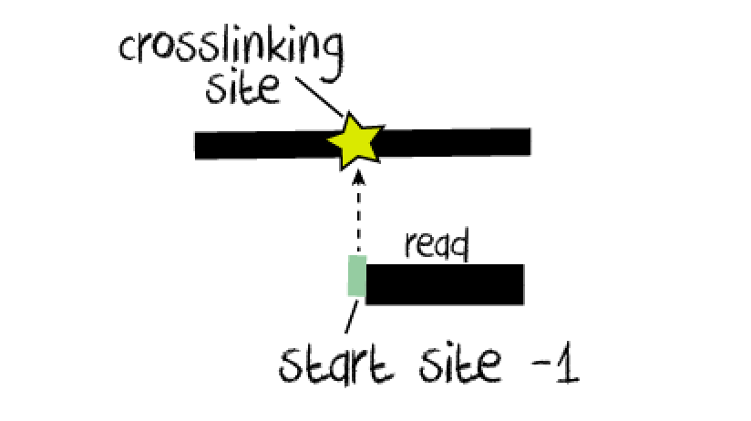

Figure 2: Truncation sites (often referred to as crosslink sites) are the neighboring position of the aligned read

In summary, iCLIP and eCLIP protocols provide count data for single-nucleotide positions which are subjected to many heuristic events which are described in the next chapter.

We will need required packages for the rest of this vignette

```r
library("IHW")
library("tidyverse")
```

## 2.2 The idea behind DEWSeq

### 2.2.1 Understanding the signal

#### 2.2.1.1 Binding modes

Unlike transcription factors, RNA-binding proteins have many different binding modes (Hentze et al. 2018), some bind sequence specific, some have preference for structures (like stem-loops), some like to bind RNA modifications, others are mostly found at UTRs etc. and most of them do not have a known RNA-binding domain and bind using disordered regions with unknown target preferences.

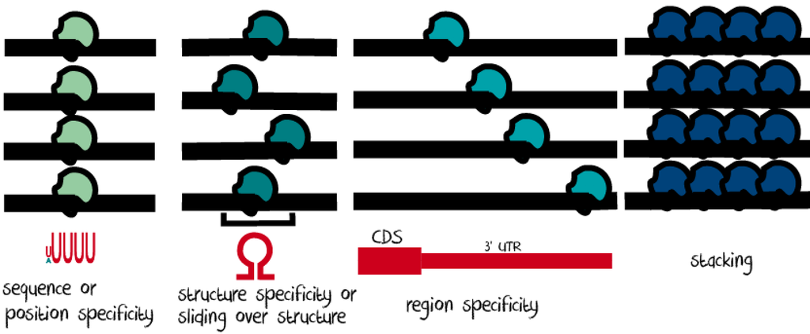

Figure 3: Different binding modes of RNA-binding proteins

All these different binding modes can result in different crosslinking patterns, hence different truncation event patterns.

#### 2.2.1.2 Chance of crosslinking

UV crosslinking at 254 nm is used to induce covalent (very strong) chemical bonds within very close proximity of RNAs to proteins. This allows a “snapshot” of the RNA binding and ensures no disassociation of the RNA-protein complexes in further steps. This process is very unfortunately rather inefficient. Typically, crosslinking with Stratlinker(R) UV crosslinkers do have an effecticity of ~1-3% or less (depending on UV lamp intensity and time of irradiation). Newer crosslinkers with lasers can go up to ~10-20% crosslinking efficiency depending on protein and setup.

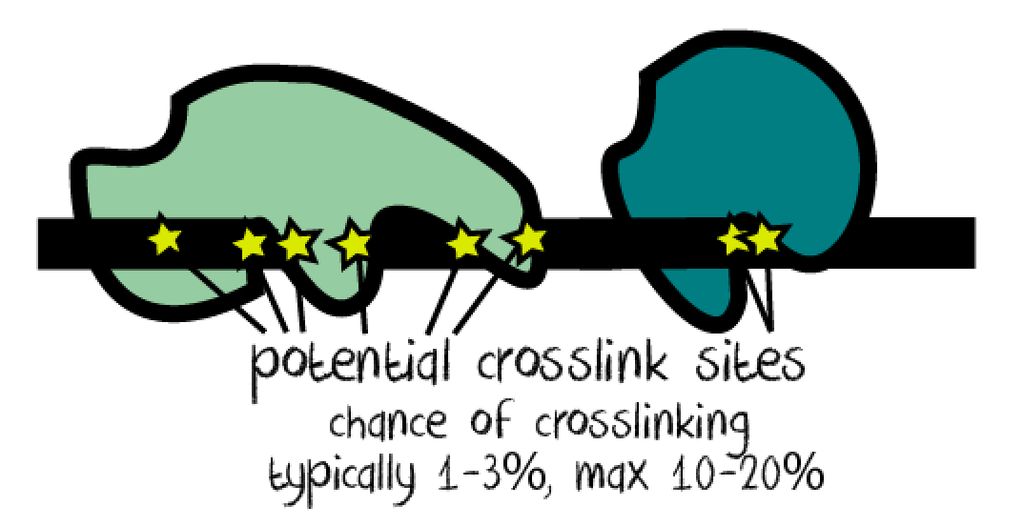

Figure 4: Chance of crosslinking

Depending on the type of protein and the binding mode, this can result in different crosslinking pattern for each protein. Crosslinking will also affect other proteins, and the IP step will only enrich for RNA fragments bound to the RNA and crosslinked samples show a certain background different to normal expression patterns measured by RNA-sequencing.

#### 2.2.1.3 Background and antibodies

##### 2.2.1.3.1 Enrichment of targets

Immunoprecipitating your (crosslinked) protein and performing sequencing without any RNA digestion is called RIP-seq (without crosslinking) or HITS-CLIP (with crosslinking). These studies nicely show that the enrichment of your protein with antibodies recognizing protein tags or native epitops will also enrich RNA fragments bound to the protein. However it is clear that the IPed samples contain almost a full transcriptomic (random) background. Depending on the specificity of your antibody, your purification method (e.g. type of beads) and many other factors, this can vary for different proteins. The authors do not know any cases where IP steps exclusively purify targets, if you find any cases, please contact the authors, we would really like to know.

##### 2.2.1.3.2 Contaminants vs background

If you take a close look to the first iCLIP analysis protocols (and lot of protocols to date), you will notice that snoRNAs, lincRNAs and other short RNAs are excluded from the protocol althought they make up a majority of the signal. They were either treated as contaminants and dismissed right away, or more recently it was recommended to intersect the data with an orthogonal data like RNA-seq knockouts and only look at the regions of interest. As already mentioned, it was shown that size-matched input (SMI) controls can control for different artifacts from crosslinking and library preparation (Eric L Van Nostrand et al. 2016) and after correction it is possible to detected real lincRNC, snoRNA etc binders.

Crosslinked samples do have a different backgroud compared to expression levels (as detected with RNA-seq). Therefore it is of great importance to compare the IPed sample to a proper input control. *SMI controls can be easily applied for any CLIP protocols*.

#### 2.2.1.4 RNA fragment length and RNase concentrations

To narrow down the target RNAs to the binding site region, RNase is used to digest RNA not protected by your protein. Using different RNase concentration will result in different RNA fragment lengths. Also, if your protein is stacked tighly together protecting a larger area from digestion, this can result in longer RNA fragments which can affect the crosslinking pattern (Haberman et al. 2017).

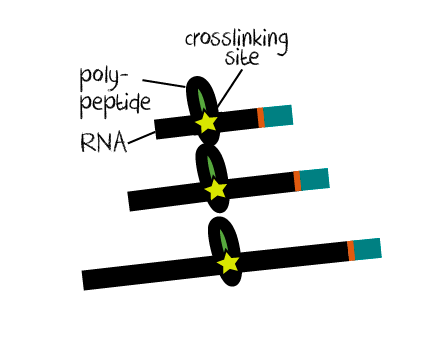

Figure 5: Different RNase concentrations will result in different fragment sizes

#### 2.2.1.5 Read-throughs

iCLIP and eCLIP depend on the truncation of the reverse transcriptase at crosslink sites. In contrast, HITS-CLIP and PAR-CLIP need reverse transcriptases reading through the crosslink sites. Both methods use different reverse transcriptases with different likelihood of truncating or reading through. The chance of this event will also be affected by the polypeptide which is left after protein digestion of the protein of interest.

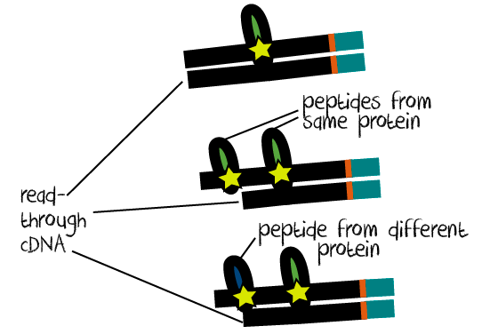

Figure 6: Read-throughs

“Read-throughs” can truncate at a crosslink site from the same proteins, a different protein, a RNA modifications, any other unknown events or finish at the end of an RNA fragment. Due to the low efficency the crosslinking of multiple proteins is usually less likely, however not no improbable.

##### 2.2.1.5.1 Early truncations

Early truncations can also appear on a long RNA fragment with multiple crosslink sites from different proteins or multiple crosslink sites from the same protein. Again, although low crosslinking efficency reduces the chance of having multiple crosslink sites at once, those events occur stochastically.

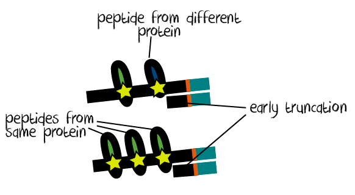

### 2.2.2 Method

#### 2.2.2.1 Differentially expressed sliding windows

Because of the properties of eCLIP or iCLIP data described above, we use a sliding window approach (where different window and step sizes can be chosen in the preprocessing) and test for significant enrichment in the IP over the control. For this, we extended *DESeq2* for a one-sided wald test to filter windows with negative wald stat values and do a right-tailed test on the remaining windows. The filtering step increases the performance when testing millions of windows.

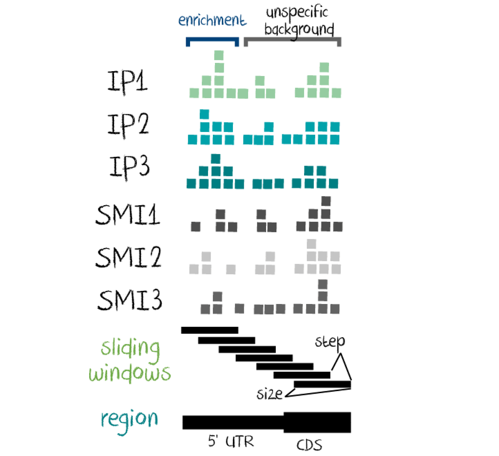

#### 2.2.2.2 Combining significant windows

Contrary to large fragments detected in ChIP-seq, the truncation sites are only one nucleotide. To combine windows, *csaw* defines ChIP-seq binding regions which are then subjected to multiple hypothesis correction.

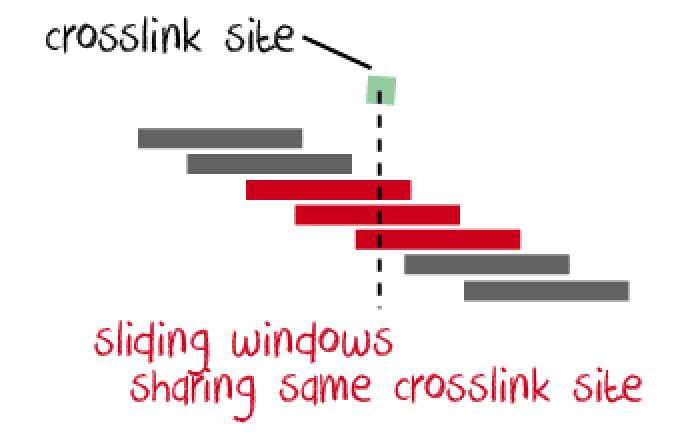

Figure 7: Sliding window approach with single-nucleotide position count data

Then we apply multiple hypothesis correction.

## 2.3 Prerequisits for DEWSeq

Most importantly, replicates and input controls are required for the significance testing for DEWSeq. Currently, we only allow the use of *DESeq2*’s wald test, not the LRT test for complexer models. This will implemented later. If you want to use complexer models, you might want to contact the authors.

### 2.3.1 True input controls

Typically, CLIP-seq samples do have a lot of background which comes from a mix of various transcripts with different expression levels. Additionally, UV crosslinking does not affect RNAs in a linear fashion, therefore an appropriate input control is needed for the analysis of eCLIP/iCLIP data. Unfortunately, total RNA-seq does not reflect the UV crosslinked background, also IgG-, empty beads, or similar controls are not appropriate input controls. We recommend size-matched input controls (SMI) controls as performed in the eCLIP protocol (Eric L Van Nostrand et al. 2016). This type of input control is not protocol specific, therefore can be easily adapted to iCLIP or other CLIP studies. Most importantly, it can control for truncations caused by interferences.

We recommend to use IgG or empty beads controls to flag (expression dependent) regions for optional removal.

### 2.3.2 Replicates

Biological replicates in high-throughput studies are needed in the significance testing process to ensure reproducibility of the results. Please refer to the *csaw* package for discussion on this topic.

In general, we recommend to ask yourself how many replicates would you use when performing RNA-seq. Usually, the answer is, at least three for the sample and three for the control (depending on many experimental factors which also will apply for your CLIP study). As a tumb of rule, your number of replicates ideally should not be less if you are interested in an transcriptome wide analysis of your RNA-binding protein.

# 3 Data preprocessing

DEWSeq needs a countmatrix and preprocessed annotation. The preprocessing is done in two general steps.

1. Raw data preprocessing, alignment and PCR duplication removal
2. Extraction of crosslink sites, preprocessing of annotation and counting.

## 3.1 Raw data preprocessing: From fastq to bam files

eCLIP or iCLIP data preprocessing can be extensive and time-consuming. Generally the steps for preprocessing are:

- Unique Molecular Identifiers (UMIs) extraction and demultiplexing ([Je Suite](https://gbcs.embl.de/portal/tiki-index.php?page=Je), or other tools). Usually the UMI is extracted from the fasta sequence and put into the header. Different tools put it at different locations (beginning or end of fastq header).
- Read quality filtering (optional)
- Trimming of sequencing adapters (with tools like [cutadapt](https://cutadapt.readthedocs.io))
- Second trimming step (extremely important for paired-end (standard) eCLIP libraries). This is needed because a ‘bug’ in the standard paired-end eCLIP protocol. Hint: Single-read seCLIP (Eric L. Van Nostrand et al. 2017) has a lot of advantages to standard, paired-end eCLIP, one of them is that you can skip this preprocessing step.
- Quality Control ([fastqc](https://github.com/s-andrews/FastQC) with [multiqc](https://multiqc.info/) summary statistics or similar).
- Alignment ([Novoalign](http://www.novocraft.com/products/novoalign/), STAR, or other (splice-aware) aligners, depending on your organisms)
- PCR duplication removal also called UMI evaluation [Je Suite](https://gbcs.embl.de/portal/tiki-index.php?page=Je) or custom tools depending on your protocol and single-read or paired-end setup. Please use tools which consider sequencing errors in the UMI and read sequences.
- Sort and index bam files (samtools or similar)

Eventually, you will end up with sorted *.bam* files.

## 3.2 Crosslink site extraction and counting: From bam and gff3 files to count matrix and annotation

htseq-clip is the preprocessing pipeline developed for the use for DEWSeq, but other tools may be used. htseq-clip does

- extract sites (typically crosslink sites)
- flatten the annotation and create an annotation mapping file
- generate sliding windows from the flattened annotation
- count sites for the sliding windows
- create count matrices

in addition it will

- split the annotation into UTRs, CDS
- count non-overlapping regions (UTRs, CDS, exons, introns, etc) for enrichment plots or DESeq2 analysis
- calculating the site distance to exon/intron junctions

htseq-clip is provided as a singularity container and comes with a Snakemake workflow for processing on local computers, servers, or computer clusters.

All you need is

- .bam files (PCR duplication removed, sorted)
- .bam.bai index files
- .gff3 files (Preferrably from Gencode or similar)

Please find all information, the documentation and downloads can be found here: http://www.hentze.embl.de/public/htseq-clip/

Tip: You can use Sailfish, Kallisto, RSEM, Salmon or any (pseudo)aligner to get an estimation of the different expression levels of transcripts. Use this to filter the annotation before flattening it.

# 4 Detection of enriched regions with DEWSeq

DEWSeq uses a sliding window approach with DESeq2 for enriched binding sites.

## 4.1 Load the library

First step is to load the library with this command

```r
require(DEWSeq)
```

## 4.2 Importing data for DEWSeq

### 4.2.1 Load test data

Use this command to load the ENCODE SLBP data set.

```r
data(SLBP_K562_w50s20)
```

This data contains two IP and one input control (SMI) samples which is not ideal, however it is small enough as test data.

```r
ddw <- SLBP_K562_w50s20
ddw
```

```
## class: DESeqDataSet
## dim: 28569 3
## metadata(1): version
## assays(1): counts
## rownames(28569): ENSG00000225630.1:exon0001W00014
##   ENSG00000225630.1:exon0001W00015 ...
##   ENSG00000210196.2:exon0001W00001 ENSG00000210196.2:exon0001W00002
## rowData names(8): unique_id gene_id ... Total_nr_of_region
##   window_number
## colnames(3): IP1 IP2 SMI
## colData names(1): type
```

### 4.2.2 From count matrix

We need to read in the

- count matrix and the (UNIQUE_ID, counts per sample)
- annotation file (UNIQUE_ID, chromosome locations, other info)

which can be prepared with htseq-clip (see above)

For this, we recommend data.table or tidyr packages to read in the data swiftly. To data data.table is significantly faster than tidyr.

```r
library(tidyverse)
library(data.table)
```

First we read in counts

```r
countData <- fread("path/swcounts/count_matrix.txt.gz", sep = "\t")

# or alternatively with tidyr:
# countData <- read_tsv("path/swcounts/count_matrix.txt.gz")
```

Then we read in the annotation data frame

```r
annotationData <- fread("path/annotation/annotation.txt.gz", sep = "\t")

#or alternatively with tidyr:
#annotationData <- read_tsv("path/annotation/annotation.txt.gz")
```

Finally we have to create a sample description

```r
colData <- data.frame(
  row.names = colnames(countData),
  type      = factor(
                c(rep("IP", 3),    ##  change this accordingly
                  rep("SMI", 3)),  ##
                levels = c("IP", "SMI"))
)
```

This function will parse the annotation file and create a DESeq object

```r
ddw <- DESeqDataSetFromSlidingWindows(countData  = countData,
                                      colData    = colData,
                                      annotation = annotationData,
                                      tidy       = TRUE,
                                      design     = ~type)
```

This will return a DESeq object with the coordinates and annotation stores as rowAnnotation.

## 4.3 Prefiltering

Prefiltering becomes even more important with large numbers of sliding windows. Please find more details here: http://bioconductor.org/packages/devel/bioc/vignettes/DESeq2/inst/doc/DESeq2.html#pre-filtering

```r
keep <- rowSums(counts(ddw)) >= 10
ddw <- ddw[keep,]
```

## 4.4 Estimating Size Factors

The standard procedure to estimate size factors is

```r
ddw <- estimateSizeFactors(ddw)
```

### 4.4.1 Estimate size factors based on a specific set of RNAs

CLIP data often shows high expression of RNA contaminations, therefore you might want to normalise based on protein coding genes only

```r
ddw_mRNAs <- ddw[ rowData(ddw)[,"gene_type"] == "protein_coding", ]
ddw <- estimateSizeFactors(ddw_mRNAs)
rm(ddw_mRNAs)
```

## 4.5 Differential expressed windows analysis

Estimate the dispersions and perform the wald test with these two functions. Please note, currently, DEWSeq does not support LRT tests.

```r
ddw <- estimateDispersions(ddw)
ddw <- nbinomWaldTest(ddw)
```

This performes a one-sided signficance test, looking for enrichment in the IP samples vs the SMI controls. Also it will perform a correction for p-values of overlapping windows: The function will determine how many overlapping windows for each window there are (this can vary at the end of features, e.g. a gene) and then perform Bonferroni for each window.

These family-wise corrected windows will corrected for multiple testing with Benjamini-Hochberg.

```r
resultWindows <- resultsDEWSeq(ddw,
                              contrast = c("type", "IP", "SMI"),
                              tidy = TRUE) %>% as_tibble

resultWindows
```

```
## # A tibble: 4,277 x 20
##    unique_id chromosome  begin    end width strand gene_id gene_name
##    <chr>     <chr>       <dbl>  <int> <int> <fct>  <chr>   <chr>
##  1 ENSG0000… chr1       1.06e6 1.06e6    50 +      ENSG00… AGRN
##  2 ENSG0000… chr1       1.06e6 1.06e6    50 +      ENSG00… AGRN
##  3 ENSG0000… chr1       1.06e6 1.06e6    50 +      ENSG00… AGRN
##  4 ENSG0000… chr1       7.96e6 7.96e6    50 +      ENSG00… PARK7
##  5 ENSG0000… chr1       1.10e7 1.10e7    50 +      ENSG00… TARDBP
##  6 ENSG0000… chr1       1.10e7 1.10e7    50 +      ENSG00… AL109811…
##  7 ENSG0000… chr1       1.10e7 1.10e7    50 +      ENSG00… TARDBP
##  8 ENSG0000… chr1       1.69e7 1.69e7    50 +      ENSG00… CROCC
##  9 ENSG0000… chr1       1.69e7 1.69e7    50 +      ENSG00… CROCC
## 10 ENSG0000… chr1       2.37e7 2.37e7    50 +      ENSG00… RPL11
## # … with 4,267 more rows, and 12 more variables: gene_type <chr>,
## #   gene_region <chr>, Nr_of_region <int>, Total_nr_of_region <int>,
## #   window_number <int>, baseMean <dbl>, log2FoldChange <dbl>, lfcSE <dbl>,
## #   stat <dbl>, pvalue <dbl>, pBonferroni <dbl>, pBonferroni.adj <dbl>
```

You might be interested to correct for multiple hypothesis testing with IHW.

```r
resultWindows[,"p_adj_IHW"] <- adj_pvalues(ihw(pBonferroni ~ baseMean,
                     data = resultWindows,
                     alpha = 0.05,
                     nfolds = 10))
```

Here some basic stats about the differentially expressed windows:

```r
resultWindows <- resultWindows %>% mutate(significant = resultWindows$p_adj_IHW < 0.05)

sum(resultWindows$significant)
```

```
## [1] 672
```

672 windows are significant. Here are the top 20 from 69 genes:

```r
resultWindows %>% filter(significant) %>% arrange(desc(log2FoldChange))  %>% .[["gene_name"]] %>% unique %>% head(20)
```

```
##  [1] "HIST1H4J"  "HIST1H2BF" "HIST1H3J"  "HIST1H4H"  "HIST1H2BD" "HIST1H2BL"
##  [7] "HIST1H4B"  "HIST1H2BJ" "HIST1H2BG" "HIST1H2AG" "HIST1H4C"  "HIST1H3D"
## [13] "HIST1H3H"  "HIST1H4I"  "HIST1H2BN" "HIST1H1E"  "H2AFX"     "HIST1H4E"
## [19] "HIST2H2BE" "HIST1H2BC"
```

SLBP is an histone-RNA binding protein, so we are quite happy to see that the majority of the hits are coming from histone genes.

## 4.6 Combining regions

`resultWindows` contains information about the differential expression of windows. Now we would like to combine overlapping windows to a binding region.

```r
resultRegions <- extractRegions(windowRes  = resultWindows,
                                padjCol    = "p_adj_IHW",
                                padjThresh = 0.05,
                                log2FoldChangeThresh = 0.5) %>% as_tibble
```

Since we already corrected for the family wise error, we use the `extractRegions` function to combine the overlapping significant windows and provide metrics for best and worst p-adjusted value, as well as best and worst log2 fold change.

```r
resultRegions
```

```
## # A tibble: 134 x 21
##    chromosome region_begin region_end strand windows_in_regi… region_length
##    <chr>             <dbl>      <int> <fct>             <dbl>         <int>
##  1 chr1           21727930   21728020 -                     2            90
##  2 chr1           35189325   35189375 -                     1            50
##  3 chr1          149812085  149812155 -                     2            70
##  4 chr1          149813270  149813380 -                     4           110
##  5 chr1          149813410  149813460 -                     1            50
##  6 chr1          149840677  149840767 -                     3            90
##  7 chr1          149842207  149842357 -                     6           150
##  8 chr1          149852978  149853048 +                     2            70
##  9 chr1          149884678  149884728 -                     1            50
## 10 chr1          149886078  149886388 -                    13           310
## # … with 124 more rows, and 15 more variables: padj_min <dbl>,
## #   padj_mean <dbl>, padj_max <dbl>, log2FoldChange_min <dbl>,
## #   log2FoldChange_mean <dbl>, log2FoldChange_max <dbl>,
## #   regionStartId <chr>, gene_id <fct>, gene_name <chr>, gene_type <chr>,
## #   gene_region <chr>, Nr_of_region <dbl>, Total_nr_of_region <dbl>,
## #   window_number <dbl>, unique_ids <chr>
```

134 binding regions were found which can exported as BED file so you can browse the regions in your genome browser of choice or use it for further analyses.

```r
toBED(windowRes = resultWindows,
      regionRes = resultRegions,
      fileName  = "enrichedWindowsRegions.bed")
```

Further analyses which can be done is enrichment of gene types, sequence motif analysis of the regions, secondary structure analysis of binding regions and other functional analyses.

# 5 Discussion

## 5.1 QC

### 5.1.1 What about quality control plots etc?

In this vignette, we left out plotting of estimates dispersions and other quality control plots like MA or PCA plots. Please find very detailed explanation of those in the *DESeq2* vignette.

## 5.2 Normalisation

#### 5.2.0.1 Advanced normalisation

Normalisation might be adjusted for your proteins.

In general, it is a good strategy to call differentially expressed windows, then exclude that regions for normalisation and rerun the workflow.

## 5.3 Feedback

The authors very much welcome any feedback, comments and suggestions.

# References

Haberman, Nejc, Ina Huppertz, Jan Attig, Julian König, Zhen Wang, Christian Hauer, Matthias W. Hentze, et al. 2017. “Insights into the design and interpretation of iCLIP experiments.” *Genome Biology* 18 (1). doi:10.1186/s13059-016-1130-x.

Hafner, Markus, Markus Landthaler, Lukas Burger, Mohsen Khorshid, Jean Hausser, Philipp Berninger, Andrea Rothballer, et al. 2010. “Transcriptome-wide Identification of RNA-Binding Protein and MicroRNA Target Sites by PAR-CLIP.” *Cell* 141 (1): 129–41. doi:10.1016/j.cell.2010.03.009.

Hentze, Matthias W., Alfredo Castello, Thomas Schwarzl, and Thomas Preiss. 2018. “A brave new world of RNA-binding proteins.” doi:10.1038/nrm.2017.130.

König, Julian, Kathi Zarnack, Gregor Rot, Toma Curk, Melis Kayikci, Blaž Zupan, Daniel J. Turner, Nicholas M. Luscombe, and Jernej Ule. 2010. “ICLIP reveals the function of hnRNP particles in splicing at individual nucleotide resolution.” *Nature Structural and Molecular Biology* 17 (7): 909–15. doi:10.1038/nsmb.1838.

Van Nostrand, Eric L, Gabriel A Pratt, Alexander A Shishkin, Chelsea Gelboin-Burkhart, Mark Y Fang, Balaji Sundararaman, Steven M Blue, et al. 2016. “Robust transcriptome-wide discovery of RNA-binding protein binding sites with enhanced CLIP (eCLIP).” *Nature Methods* 13 (November 2015): 1–9. doi:10.1038/nmeth.3810.

Van Nostrand, Eric L., Thai B. Nguyen, Chelsea Gelboin-Burkhart, Ruth Wang, Steven M. Blue, Gabriel A. Pratt, Ashley L. Louie, and Gene W. Yeo. 2017. “Robust, cost-effective profiling of RNA binding protein targets with single-end enhanced crosslinking and immunoprecipitation (SeCLIP)” 1648: 177–200. doi:10.1007/978-1-4939-7204-3_14.